# Econometría Aplicada con R

Sesión 01: Introducción a la programación

Javier Emmanuel Anguiano Pita

SECIHTI-Universidad de Guadalajara

15 de junio de 2026

# ¡Bienvenidos al curso!

## Introducción

**Instructor:**

- Economista y Doctor en Estudios Económicos por la UDG (2022).
- Líneas de investigación:
  - Economía Internacional.
  - Macroeconomía.
  - Desarrollo económico.
- Usuario de R desde hace + 10 años.

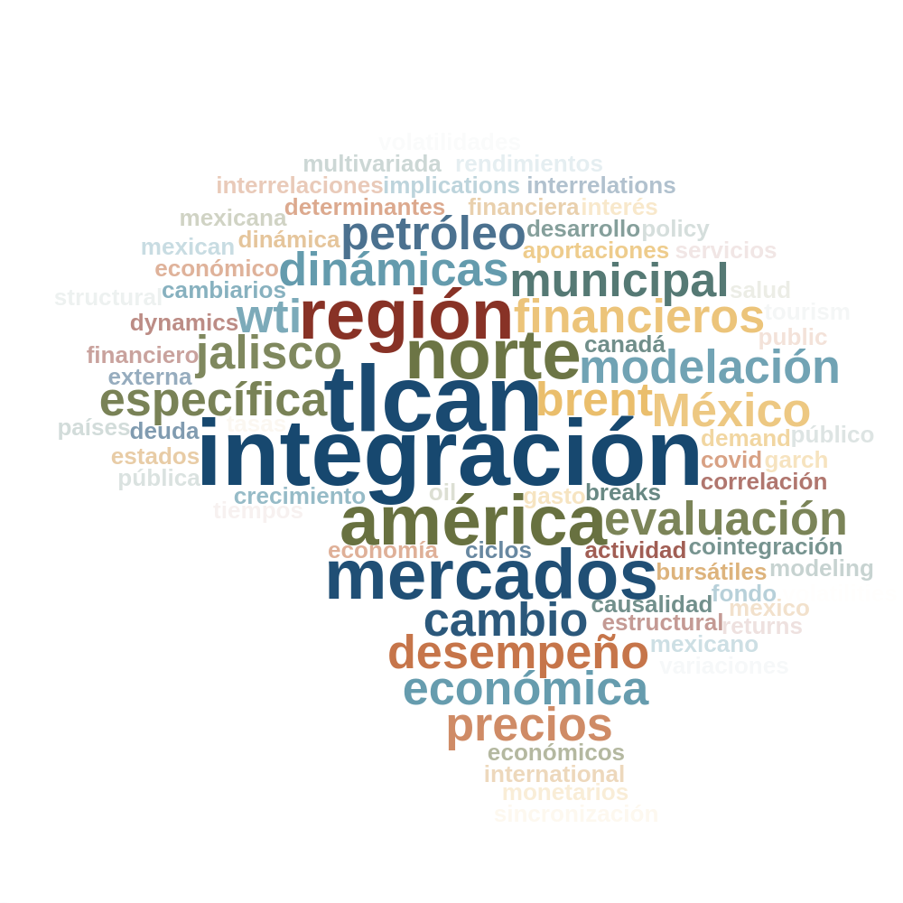

# Presentación de los asistentes

- ¿Cuál es tu nombre?
- Antecedentes académicos (BSc/MSc)
- ¿Qué tema investigan o les gustaría investigar?
- ¿Tienes experiencia en programación?

## Sobre el curso

**Objetivo principal:** Aprender a programar en `R` para desarrollar nuestras propias investigaciones.

**Estructura del curso:** 10 sesiones (~3 h cada una) diseñadas para introducirlos al flujo de trabajo para la investigación empírica y recapitular temas de Econometría II.

1. Introducción a la programación en el lenguaje `R`.
2. Modelo de regresión lineal.
3. Incumplimiento de los supuestos MCO.
4. Series de tiempo.
5. Datos en panel y sistemas de ecuaciones.
6. Modelos de variable dependiente discreta y limitada.

## Agenda del día

1. Introducción a `R` y `RStudio`
2. Programación funcional
3. Flujo de trabajo y manipulación de datos

# Motivación

## ¿Qué es `R`?

`R` es un lenguaje de programación que se utiliza principalmente para el análisis estadístico y la visualización de datos.

[figure not shown]

## ¿Por qué usar `R`?

1. `R` es un lenguaje muy flexible y poderoso- adaptable a casi cualquier tarea de investigación (análisis de datos, econometría, análisis espacial, machine learning, web scraping, etc.).
2. `R` tiene una comunidad en línea que colabora para resolver cualquier problema.
3. `R` permite crear investigación reproducible, mostrando el flujo completo del procesamiento de datos. 😉
4. `R` es gratuito y de código abierto 💰💵💰.

[figure not shown]

## Diferencias entre `R` y `Python`

| Característica | R | Python |
| --- | --- | --- |
| Alcance | Análisis y modelación estadística | Escalable. Desarrollo de aplicaciones y análisis de datos |
| Usado por | Analistas, investigadores, científicos de datos | Desarrolladores, programadores e ingenieros de datos |
| Útil para | Personas sin experiencia previa en programación | Novatos y profesionales de IT |
| Repositorio central | CRAN | PyPI |
| Visualización | ggplot2, plotly, ggiraph | Matplotlib, seaborn, ggplot |

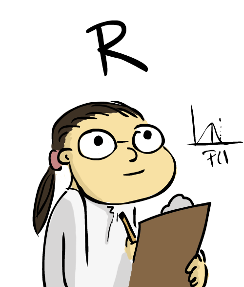

## ¿Qué es el *vibe coding*?

### Andrej Karpathy · Feb 2, 2025

> *“There’s a new kind of coding I call vibe coding, where you fully give in to the vibes, embrace exponentials, and **forget that the code even exists**.”*

**¿Qué implica?**

- Describes tu intención en lenguaje natural
- El LLM genera el código
- Aceptas cambios sin revisar/entender
- Pegas los errores de vuelta al modelo
- El código crece más allá de tu comprensión

⚠️**Debemos aprender a programar**

[figure not shown]

**Andrej Karpathy**  
Co-fundador de OpenAI  
Ex-director de IA en Tesla

# ¿Cómo usar `R`?

## `RStudio`

[figure not shown]

- Es un entorno de desarrollo integrado (IDE, en inglés) desarrollado por Posit que nos permite tener una interfaz amigable para R 😁
- `R` = 🧠
- `RStudio` = 🖱️

## Interfaz de `RStudio`

[figure not shown]

## Editor de código fuente (I)

¡Estaremos la mayor parte del tiempo aquí! En este panel escribimos y guardamos nuestro código. (File > New File > R Script) 📌 **Recordatorio**: Siempre guarda tu código.

- Usamos `#` para hacer comentarios en el código. Todo lo que esté después de este símbolo es ignorado por R hasta la línea siguiente.
- Para mejorar la claridad de nuestro script separamos los comandos con **saltos de línea**.
- Los espacios en una misma línea no implican cambiar de comando.

## Editor de código fuente (II)

Ejemplo:

```r
1 + 1 # ¿Es igual a dos?
1 +   # ¿También es igual a dos?
  1   # R sigue esperando instrucciones
1
+ 1   # Es igual a uno
```

## Consola

**El medio de comunicación entre nuestro código y el cerebro de R** 🤖

- Escribimos las instrucciones después del símbolo `>`. Esto significa que R está listo para nuestras instrucciones.
- Podemos escribir instrucciones directamente en la consola e incluso hacer cálculos rápidos.
- Los resultados se guardan temporalmente en la memoria de R.

⚠️**Escribe todo tu código como script para poder replicarlo**

## Entorno de trabajo

**Aquí podemos hacer un seguimiento de lo que hacemos** 🖇️

- `R` es un lenguaje **orientado a objetos**. Esto significa que nosotros manipulamos y modificamos las características de dichos objetos.
- La pestaña `History` lleva un registro de todo lo que hacemos y se guarda temporalmente en la sesión de `R`.
- Cada que iniciamos `RStudio` se inicia una nueva sesión en `R`. Tenemos varios 🧠
- Para guardar un objeto en la memoria de `R` podemos usar dos tipos de operadores de asignación : `<-` y `=`.

## Files / Plots / Help / Packages/ etc.

**Este panel tiene muchas cosas útiles** 🏆

- La pestaña `Files` nos indica el directorio de trabajo de R.
- La pestaña `Plots` muestra los gráficos que generamos en nuestro script.
- La pestaña `Help` es útil para conocer la documentación de las librerías y funciones que podemos usar en R.
- Podemos usar el comando `?` antes del nombre de cualquier función o librería para obtener ayuda. P.ej. `?getwd()`
- La pestaña `Packages` nos muestra todas las librerías que tenemos instaladas y podemos invocar/desactivar en la sesión activa de R.